# Worked Example: Arthritis

Johan Larsson

## Arthrithis

In this worked example we will be working with data from a treatment trial for Arthritis. The data comes from the [vcd package](https://CRAN.R-project.org/package=vcd). To begin, let’s load the package and take a `glimpse()` at the data.

```r
# install.packages("vcd") # if you haven't installed it yet
library(vcd)
library(tidyverse)

glimpse(Arthritis)
```

```
## Rows: 84
## Columns: 5
## $ ID        <int> 57, 46, 77, 17, 36, 23, 75, 39, 33, 55, 30, 5, 63, 83, 66, 4…
## $ Treatment <fct> Treated, Treated, Treated, Treated, Treated, Treated, Treate…
## $ Sex       <fct> Male, Male, Male, Male, Male, Male, Male, Male, Male, Male, …
## $ Age       <int> 27, 29, 30, 32, 46, 58, 59, 59, 63, 63, 64, 64, 69, 70, 23, …
## $ Improved  <ord> Some, None, None, Marked, Marked, Marked, None, Marked, None…
```

Notice that `Improved` is helpfully formatted as an ordinal (ordered) variable already, which is going to help ggplot to choose the correct color palettes for us.

## Bar Charts

Let’s start with a simple bar chart to see how many people were allocated to the two treatment arms.

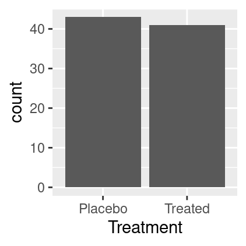

Treatment allocation for the arthritis study.

```r
library(tidyverse)

ggplot(Arthritis, aes(Treatment)) +
  geom_bar()
```

### Was the Treatment Effective?

Now for something more interesting. Let’s try to look at how well the treatment seems to have worked. We start with a stacked bar chart.

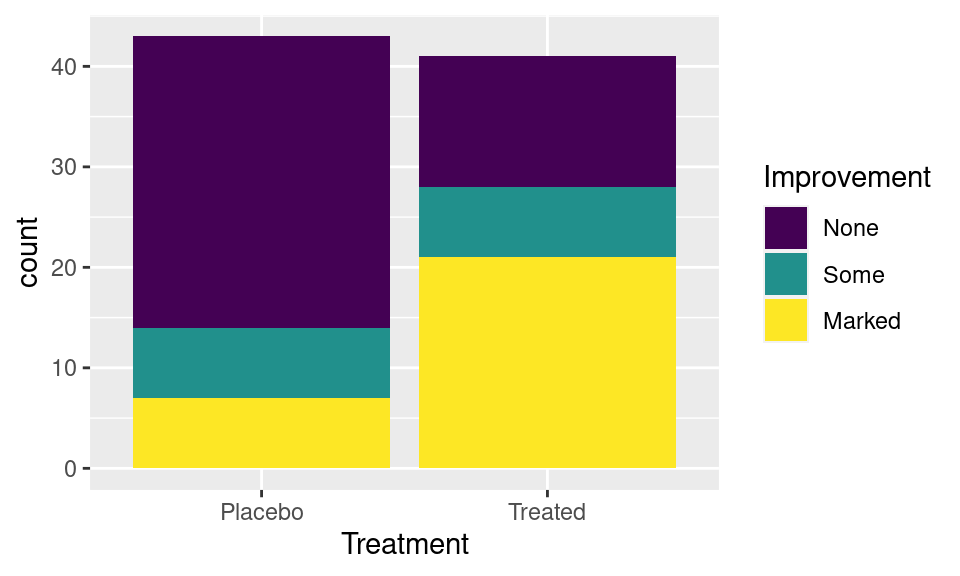

Treatment effect in the arthritis study.

```r
ggplot(Arthritis, aes(Treatment, fill = Improved)) +
  geom_bar() +
  labs(fill = "Improvement") # add a better legend title
```

It’s immediately clear that the treatment has worked well! The count of people with a improvement is much higher in the treatment arm compared with the placebo arm. But how do the treatments compare when it comes to people who’ve made *some* improvement? This is difficult to say from our approach here. This is due to two reasons:

1. The stacked bar chart makes it very hard to compare all but the first category, since the other portions of the bars are not aligned.[^1]
2. The bars are not proportional.[^2]

Let’s try a grouped proportional bar chart instead. To do this, we need to do a little more work since there is no direct option to do this in ggplot2. Our two choices are:

1. use `group_by()` and `summarize()` to compute the proportions we need directly, and then plot the bar chart with `geom_col()` or
2. use `after_stat()`.

We will try the second option here. We start with the code.

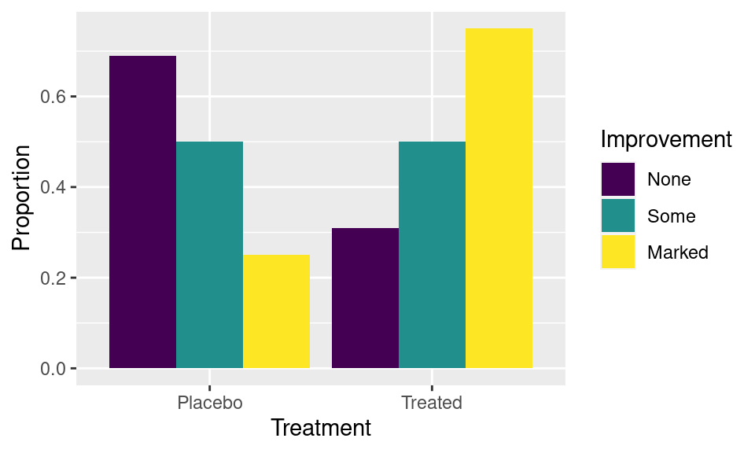

Grouped, proportional bar chart of the arthritis data.

```r
Arthritis %>%
  ggplot(aes(Treatment, group = Improved, fill = Improved)) +
  geom_bar(aes(y = after_stat(prop)), position = "dodge") +
  labs(fill = "Improvement",
       y = "Proportion")
```

So how does this work? The key to this is that `geom_bar()` computes (and makes accessible) certain statistics. Among these are `prop`, which is the *group-wise* proportion. To access this statistic, we need to use the special `after_stat()` function, which acts as a wrapper that evaluates its arguments after the statistics in the enclosing function have been computed. To get this to work properly, we also need to map the `group` aesthetic, so that ggplot knows which category to compute proportions within.

This strategy can be used with many other layer functions (`geom_*()` functions) in ggplot.

## Mosaic Plots

In the lecture we also encountered mosaic plots, which are proportional bar charts that map not only the height of the bars but also the width of the bars to group sizes.

In the lecture, we used the productplots package, but here we will try another solution offered by ggmosaic.

```r
# install.packages("ggmosaic") # if don't already have the package

library(ggmosaic)
```

Unlike **productplots**, **ggmosaic** works directly with a ggplot2 object, adding auxiliary functions (`geom_*()` functions) to extend its functionality.

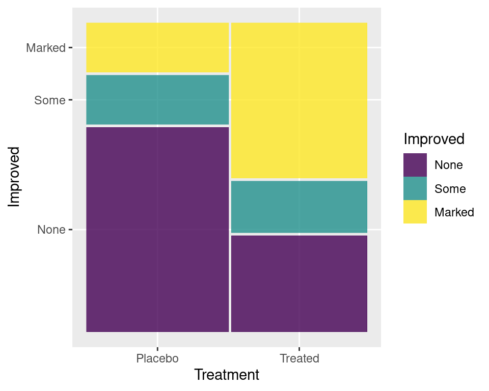

```r
ggplot(Arthritis) +
  geom_mosaic(aes(x = product(Treatment), fill = Improved))
```

The key features to notice about this call are

1. that the `aes()` specification must reside *inside* the call to `geom_mosaic()`, and not in the `ggplot()` function and
2. the call to `product()`, which acts simply as a list of variables that you want to use in the mosaic plot.

The main benefit of the mosaic plot is that we get to see more of the data. With the bar charts we needed to separate visualizations to provide information on the overall size of the groups (treatment arms), whereas with the mosaic plot we can make do with only a single plot.[^3]

## Waffle Plots

Waffle plots are easy-to-read visualizations that are actually quite uncommon in statistical visualizations but much more prevalent in media outlets such as newspapers. They are, as we mentioned in the lecture, at their best when some of the categories are so small that their sizes are hard to estimate in a barchart or mosaic plot.

There is a great package for mosaic plots that interact well with ggplot2 called waffle. Unfortunately, the current version on CRAN is outdated[^4] and much of the new functionality that makes it work well with ggplot is only available from the [development version at GitHub](https://github.com/hrbrmstr/waffle).

For that reason, waffle plots are not compulsory material in this course and will instead serve as bonus material for those who are interested.

To download development versions of R packages from GitHub, you need the the remotes package or the devtools package.

```r
# install remotes
install.packages("remotes")

# install waffle
remotes::install_github("hrbrmstr/waffle") # or devtools::install_github()
```

The waffle package requires that our data contains counts of the categories, so before we can use it, we need to do a bit of wrangling. More precisely, you need to group the data by `Improved` and `Treatment` and then use `summarize()` together with either the `n()` function to get either counts or some other expression for proportions. We’ll settle for counts in this example. Before looking at the following code, see if you can do this by yourself. The result should be a 6-row tibble with columns `Treatment`, `Improved` and `Count` (or whatever you want to call it). Save the result to an object called `Arthritis_summarized`.

```r
Arthritis_summarized <-
  Arthritis %>%
  group_by(Treatment, Improved) %>%
  summarize(Count = n())
```

Now we’re ready to start making waffles! The aesthetics you need to know about here are `fill` and `values`. Values is what we want to map the counts or proportions that we just created to and `fill` will connect our inner-most group to fill color. We start with the simplest possible waffle chart, just looking at improvement among the participants in the treatment arm.

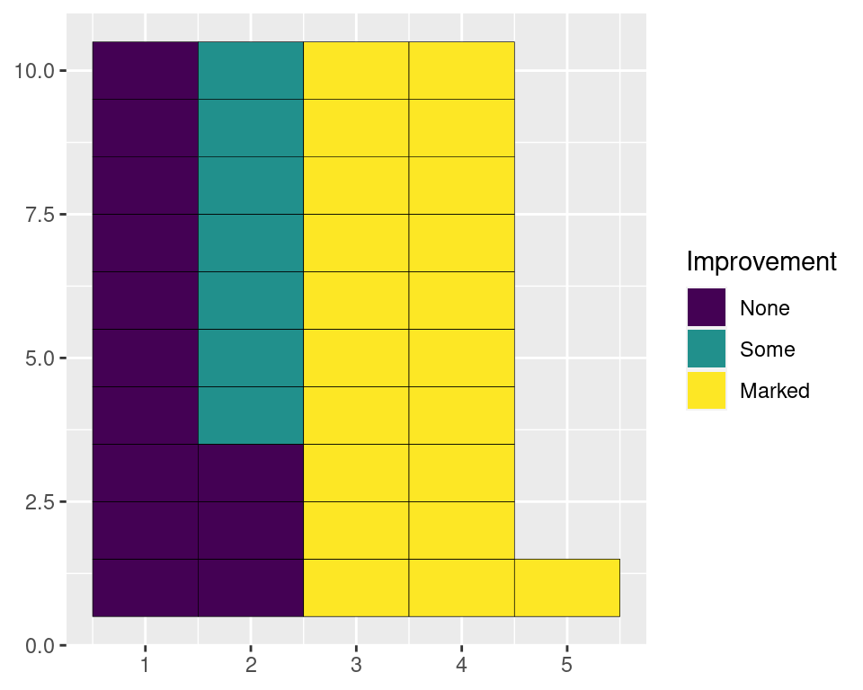

A basic waffle chart of the results from the treatment arm.

```r
library(waffle)

filter(Arthritis_summarized, Treatment == "Treated") %>%
  ggplot(aes(fill = Improved, values = Count)) +
  geom_waffle() +
  labs(fill = "Improvement")
```

This looks kind of like a waffle chart, but there’s a lot of superfluous information that we’d rather get rid off. Thankfully, **waffle** provides the helpful `theme_enhance_waffle()` function for this. Moreover, we probably prefer the symbols (rectangles) to be squares—it’s supposed to look like a waffle after all, right?—which we can accomplish by forcing the coordinate system to be isometric using `coord_equal()`. Finally, I think it looks more aesthetically pleasing if we swap the black line color for white, increase their widths slightly, and change theme to the minimal variant.

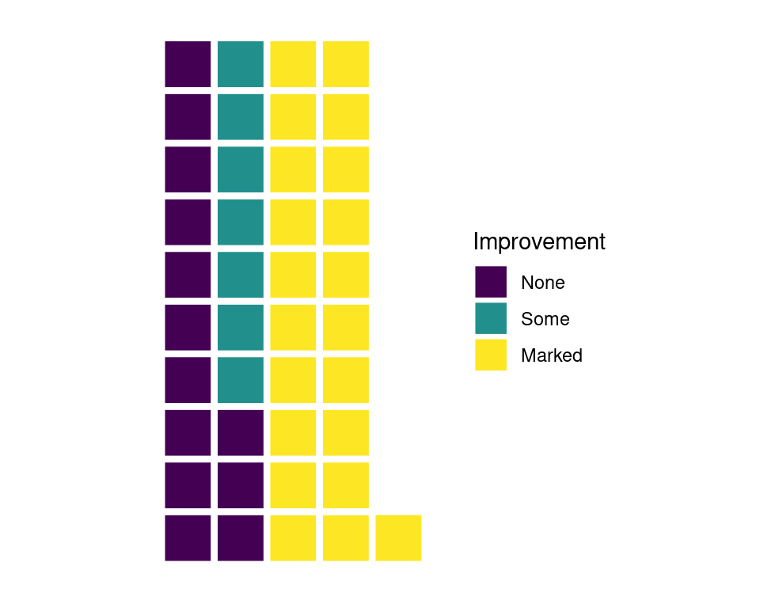

A prettier waffle plot.

```r
filter(Arthritis_summarized, Treatment == "Treated") %>%
  ggplot(aes(fill = Improved, values = Count)) +
  geom_waffle(color = "white", size = 1.5) +
  coord_equal() +
  theme_minimal() +
  theme_enhance_waffle() +
  labs(fill = "Improvement")
```

That looks much better, doesn’t it?

To wrap up, we now look to the full data set by including both treatment arms. To do this with **waffle**, you need to use facets. Here we do so via the `facet_wrap()` function, simple providing the outer category that we want to facet on.

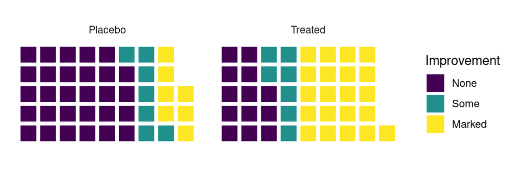

Improvement after treatment for arthritis in placebo and intervention arms.

```r
ggplot(Arthritis_summarized, aes(fill = Improved, values = Count)) +
  geom_waffle(color = "white", size = 1.5, n_rows = 5) +
  facet_wrap("Treatment") +
  coord_equal() +
  theme_minimal() +
  theme_enhance_waffle() +
  labs(fill = "Improvement")
```

If you want to make other types of pictograms (with other glyphs instead of squares), be sure to check out the examples over at https://github.com/hrbrmstr/waffle.

## Euler Diagrams

Euler diagrams are used to visualize relationships between sets. Most of you have probably encountered Venn diagrams during in your first statistics courses. Euler diagrams are like Venn diagrams but don’t have the requirement that we need to visualize intersections that are empty. Euler diagrams are only really useful when you have overlap among categories, such that observations can belong to any, all, or none of the levels of a category.

Here we’ll use the eulerr package. This package creates *proportional* Euler diagrams, trying to make the area of each intersection proportional to that intersection’s size. This is not always possible, in which case `euler()` will return an approximate fit. For this reason, it is important to always first *fit* the diagram, inspect the fit, and then finally plot it.

The simplest way to run `euler()` is to provide a named numeric vector that indicates intersections and their sizes. Here’s a simple example.

```r
# install.packages("eulerr")
library(eulerr)

fit <- euler(c("A" = 5, "B" = 2, "A&B" = 1))
```

Notice the use of the ampersand (`&`) to separate intersections here. Let’s examine the fit of the Euler diagram.

```r
fit
```

```
##     original fitted residuals regionError
## A          5      5         0           0
## B          2      2         0           0
## A&B        1      1         0           0
##
## diagError: 0
## stress:    0
```

Stress and diagError are both 0, so the fit is perfect! This will in fact always be the case for two-set combinations. No we can safely plot the result. Simply call `plot()` on `fit` to do so.

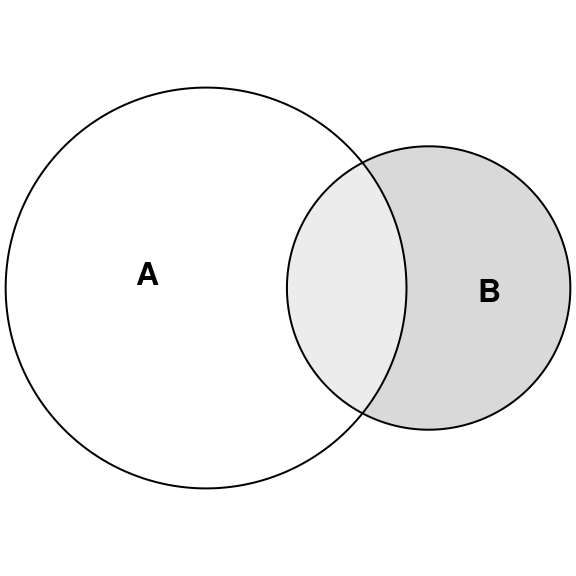

A simple Euler diagram.

```r
plot(fit)
```

`euler()` can also work directly with data, provided that the columns are factors, characters, or logicals. The arthritis data that we’ve dealt with so far, however, does not lend itself well to an Euler diagram. Can you think of why?

The reason is that most of our categories are exclusive. A person cannot be both in the treatment arm and in the placebo arm, or for that matter have made both no improvement and a marked improvement, so it is not suitable for this kind of visualization.

Instead, we’ll take a look at a dataset from the **eulerr** package called `organisms`. It contains features from a list of organisms:

```r
organisms
```

```
##         animal mammal plant   sea spiny
## cat       TRUE   TRUE FALSE FALSE FALSE
## dog       TRUE   TRUE FALSE FALSE FALSE
## lobster   TRUE  FALSE FALSE  TRUE  TRUE
## shark     TRUE  FALSE FALSE  TRUE FALSE
## whale    FALSE   TRUE FALSE  TRUE FALSE
## rose     FALSE  FALSE  TRUE FALSE  TRUE
## seaweed  FALSE  FALSE  TRUE  TRUE FALSE
```

Each value indicates for a given organism, such as a cat, whether it is an animal (yes), a mammal (yes), plant (no), and so on. We can simply call `euler()` on this data set directly.

```r
(fit_organisms <- euler(organisms)) # parantheses makes R print the object
```

```
##                               original fitted residuals regionError
## animal                               0  0.582    -0.582       0.086
## mammal                               0  0.302    -0.302       0.044
## plant                                0  0.210    -0.210       0.031
## sea                                  0  0.430    -0.430       0.063
## spiny                                0  0.166    -0.166       0.025
## animal&mammal                        2  1.817     0.183       0.018
## animal&plant                         0  0.000     0.000       0.000
## animal&sea                           1  0.612     0.388       0.053
## animal&spiny                         0  0.215    -0.215       0.032
## mammal&plant                         0  0.000     0.000       0.000
## mammal&sea                           1  0.000     1.000       0.143
## mammal&spiny                         0  0.000     0.000       0.000
## plant&sea                            1  0.868     0.132       0.015
## plant&spiny                          1  0.000     1.000       0.143
## sea&spiny                            0  0.176    -0.176       0.026
## animal&mammal&plant                  0  0.000     0.000       0.000
## animal&mammal&sea                    0  0.268    -0.268       0.040
## animal&mammal&spiny                  0  0.061    -0.061       0.009
## animal&plant&sea                     0  0.119    -0.119       0.018
## animal&plant&spiny                   0  0.000     0.000       0.000
## animal&sea&spiny                     1  0.715     0.285       0.037
## mammal&plant&sea                     0  0.000     0.000       0.000
## mammal&plant&spiny                   0  0.000     0.000       0.000
## mammal&sea&spiny                     0  0.000     0.000       0.000
## plant&sea&spiny                      0  0.016    -0.016       0.002
## animal&mammal&plant&sea              0  0.000     0.000       0.000
## animal&mammal&plant&spiny            0  0.000     0.000       0.000
## animal&mammal&sea&spiny              0  0.177    -0.177       0.026
## animal&plant&sea&spiny               0  0.043    -0.043       0.006
## mammal&plant&sea&spiny               0  0.000     0.000       0.000
## animal&mammal&plant&sea&spiny        0  0.000     0.000       0.000
##
## diagError: 0.143
## stress:    0.352
```

This doesn’t look great, unfortunately. The `stress` and `diagError` are large[^5] and if we take a look at a diagnostic plot, we’ll see that many of the areas in the plot are misrepresented.

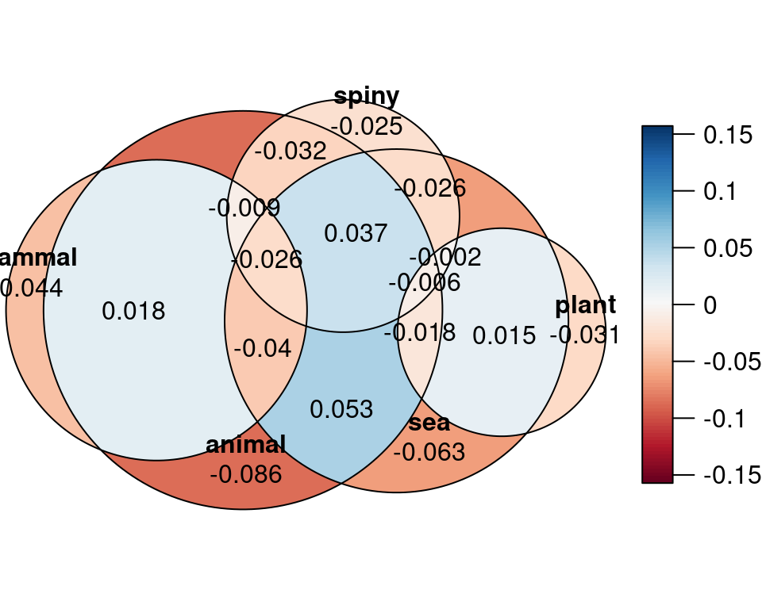

A diagonstic plot of the fit on the organisms data.

```r
error_plot(fit_organisms)
```

One alternative we can try is to use *ellipses* instead of circles. We specify this in the call to `euler()`, like so:

```r
(fit_organisms_ellipses <- euler(organisms, shape = "ellipse"))
```

```
##                               original fitted residuals regionError
## animal                               0  0.192    -0.192       0.026
## mammal                               0  0.120    -0.120       0.016
## plant                                0  0.265    -0.265       0.035
## sea                                  0  0.196    -0.196       0.026
## spiny                                0  0.174    -0.174       0.023
## animal&mammal                        2  1.977     0.023       0.021
## animal&plant                         0  0.000     0.000       0.000
## animal&sea                           1  0.976     0.024       0.012
## animal&spiny                         0  0.162    -0.162       0.022
## mammal&plant                         0  0.000     0.000       0.000
## mammal&sea                           1  0.000     1.000       0.143
## mammal&spiny                         0  0.000     0.000       0.000
## plant&sea                            1  0.913     0.087       0.021
## plant&spiny                          1  0.877     0.123       0.025
## sea&spiny                            0  0.000     0.000       0.000
## animal&mammal&plant                  0  0.000     0.000       0.000
## animal&mammal&sea                    0  0.087    -0.087       0.012
## animal&mammal&spiny                  0  0.077    -0.077       0.010
## animal&plant&sea                     0  0.071    -0.071       0.010
## animal&plant&spiny                   0  0.013    -0.013       0.002
## animal&sea&spiny                     1  0.954     0.046       0.015
## mammal&plant&sea                     0  0.000     0.000       0.000
## mammal&plant&spiny                   0  0.000     0.000       0.000
## mammal&sea&spiny                     0  0.000     0.000       0.000
## plant&sea&spiny                      0  0.191    -0.191       0.026
## animal&mammal&plant&sea              0  0.000     0.000       0.000
## animal&mammal&plant&spiny            0  0.000     0.000       0.000
## animal&mammal&sea&spiny              0  0.073    -0.073       0.010
## animal&plant&sea&spiny               0  0.153    -0.153       0.021
## mammal&plant&sea&spiny               0  0.000     0.000       0.000
## animal&mammal&plant&sea&spiny        0  0.000     0.000       0.000
##
## diagError: 0.143
## stress:    0.147
```

The stress metric has improved significantly, but not the diagError measure. Looking at the error plot, it seems like the errors are smaller than before.

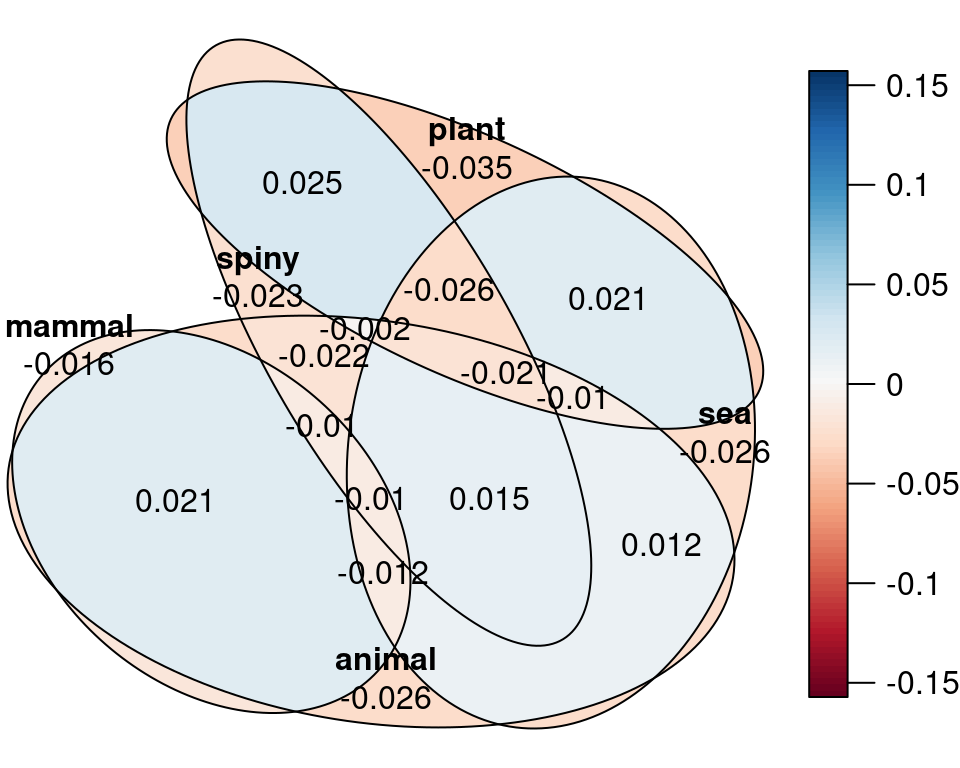

```r
error_plot(fit_organisms_ellipses)
```

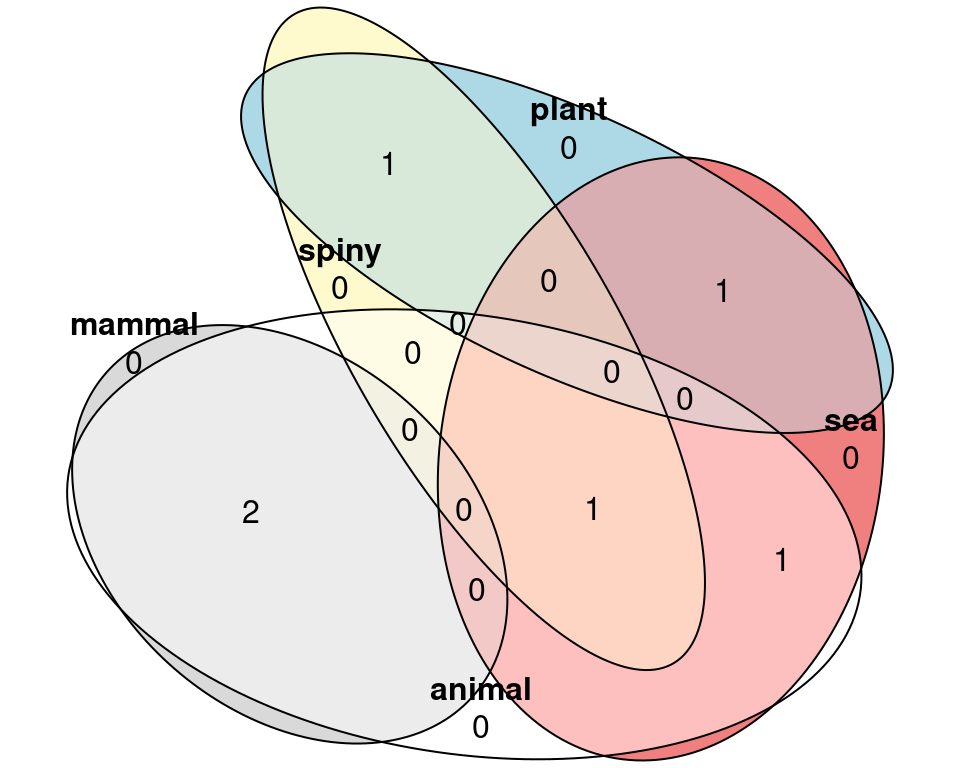

Relationships between various categorizations of organisms.

```r
# quantities = TRUE shows the number of actual observations in each
# intersection
plot(fit_organisms_ellipses, quantities = TRUE)
```

## Source Code

The source code for this document is available at https://github.com/stat-lu/STAE04/blob/master/worked-example-arthritis.Rmd.

[^1]: This is not quite as severe a problem for this particular visualization since the inner grouping variable is ordinal. For other problems, however, this can be much more detrimental to the result.
[^2]: To be fair, the differences between the group sizes are small here, but this also means that we don’t lose any information when using proportional bars instead.
[^3]: But note that it is the *relative* size that we show. If we want the actual *counts* in the outer category, we still need to add additional plots or provide this information in text.
[^4]: Feel free to voice your support for a CRAN update at https://github.com/hrbrmstr/waffle/issues/72.
[^5]: We won’t delve into what these actually mean here, but please read the documentation for the package if you are interested.